# Predicting Burglary Risk Using Graffiti as a Spatial Indicator

- Show All Code
- Hide All Code
- View Source

Assignment 4: Spatial Predictive Analysis

Author

Zicheng Xiang

Published

November 16, 2025

## Introduction

For this spatial predictive analysis, I examine **graffiti removal requests** as a potential indicator for predicting burglary patterns in Chicago. Graffiti has long been associated with “broken windows theory” - the idea that visible signs of disorder in a neighborhood may correlate with more serious crime. By analyzing whether graffiti complaints can help predict where burglaries occur, I test whether this visible indicator of neighborhood conditions has predictive power for property crime.

This analysis builds a spatial predictive model using 2017 data, validates it through spatial cross-validation, and tests its predictive accuracy on 2018 burglary data. I compare the model’s performance against a simple kernel density baseline to determine whether the added complexity of including spatial features provides meaningful improvements in prediction.

## Setup

```r
# Load required packages
library(tidyverse)      # Data manipulation
library(sf)             # Spatial operations
library(here)           # Relative file paths
library(viridis)        # Color scales
library(terra)          # Raster operations
library(spdep)          # Spatial dependence
library(FNN)            # Fast nearest neighbors
library(MASS)           # Negative binomial regression
library(patchwork)      # Plot composition
library(knitr)          # Tables
library(kableExtra)     # Table formatting
library(spatstat.geom)  # Spatial geometries
library(spatstat.explore) # KDE
library(rlang)          # For dynamic column selection

# Set options
options(scipen = 999)
set.seed(5080)

# Create visualization theme
theme_crime <- function(base_size = 11) {
  theme_void(base_size = base_size) +
    theme(
      plot.title = element_text(face = "bold", size = base_size + 1),
      plot.subtitle = element_text(color = "gray30", size = base_size - 1),
      legend.position = "right",
      panel.grid.minor = element_blank()
    )
}

theme_set(theme_crime())
```

## Part 1: Data Loading and Exploration

### Load Spatial Boundaries

I load Chicago’s spatial boundaries, using police districts for spatial cross-validation and ensuring we test the model on completely held-out geographic areas. All data is transformed to Illinois State Plane East (ESRI:102271) which uses feet as units and minimizes distortion for Chicago’s location.

```r
# Load Chicago boundary
chicagoBoundary <-
  st_read("https://raw.githubusercontent.com/urbanSpatial/Public-Policy-Analytics-Landing/master/DATA/Chapter5/chicagoBoundary.geojson") %>%
  st_transform('ESRI:102271')

# Load police districts
tmp <- st_read("https://data.cityofchicago.org/api/geospatial/24zt-jpfn?method=export&format=GeoJSON") %>%
  st_transform('ESRI:102271')

# Automatically find the district column name
dist_col <- names(tmp)[grepl("dist", names(tmp), ignore.case = TRUE)][1]
if (is.na(dist_col)) stop("No district-like column found.")

policeDistricts <- tmp %>%
  dplyr::rename(District = !!sym(dist_col)) %>%
  dplyr::select(District, geometry)
```

**Police districts loaded:** 23 districts

### Load Burglary Data

Burglaries are the outcome I want to predict. This dataset represents reported property crimes in 2017, which serve as training data. I filter for forcible entry burglaries specifically.

```r
# Load burglary data from 2017 Chicago crimes dataset
burglaries <- read_csv("data/Crimes_-_2017_20251114.csv") %>%
  # Filter for burglary crimes only
  filter(`Primary Type` == "BURGLARY") %>%
  # Filter for forcible entry
  filter(str_detect(Description, "FORCIBLE ENTRY")) %>%
  # Remove records with missing or invalid coordinates
  filter(!is.na(Latitude), !is.na(Longitude)) %>%
  filter(Latitude > 41.6, Latitude < 42.1) %>%
  filter(Longitude > -87.95, Longitude < -87.5) %>%
  # Convert to spatial object
  st_as_sf(coords = c("Longitude", "Latitude"), crs = 4326) %>%
  st_transform('ESRI:102271')
```

**Burglaries loaded:** 8116 forcible entry incidents in 2017

### Visualize Burglary Patterns

Understanding the spatial distribution of burglaries is crucial before building any model. I create both a point map and a density surface to identify clustering patterns.

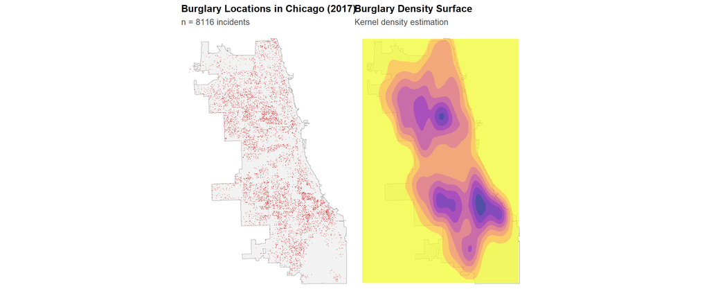

```r
# Point map
p1 <- ggplot() +
  geom_sf(data = chicagoBoundary, fill = "gray95", color = "gray60") +
  geom_sf(data = burglaries, color = "#d62828", size = 0.1, alpha = 0.4) +
  labs(
    title = "Burglary Locations in Chicago (2017)",
    subtitle = paste0("n = ", nrow(burglaries), " incidents")
  ) +
  theme_crime()

# Density surface
p2 <- ggplot() +
  geom_sf(data = chicagoBoundary, fill = "gray95", color = "gray60") +
  geom_density_2d_filled(
    data = data.frame(st_coordinates(burglaries)),
    aes(X, Y),
    alpha = 0.7,
    bins = 8
  ) +
  scale_fill_viridis_d(
    option = "plasma",
    direction = -1,
    guide = "none"
  ) +
  labs(
    title = "Burglary Density Surface",
    subtitle = "Kernel density estimation"
  ) +
  theme_crime()

p1 + p2
```

**Spatial patterns observed:** The maps reveal clear spatial clustering of burglaries. Rather than being evenly distributed across Chicago, burglaries concentrate in specific areas, suggesting that location-based factors influence crime patterns. This spatial structure motivates the use of spatial features in the predictive model.

### Load Graffiti Removal Data

```r
# Load from downloaded CSV file
graffiti <- read_csv("data/Crimes_-_2017_20251114.csv") %>%
  filter(!is.na(Latitude), !is.na(Longitude)) %>%
  st_as_sf(coords = c("Longitude", "Latitude"), crs = 4326) %>%
  st_transform('ESRI:102271') %>%
  distinct()
```

### Visualize Graffiti Distribution

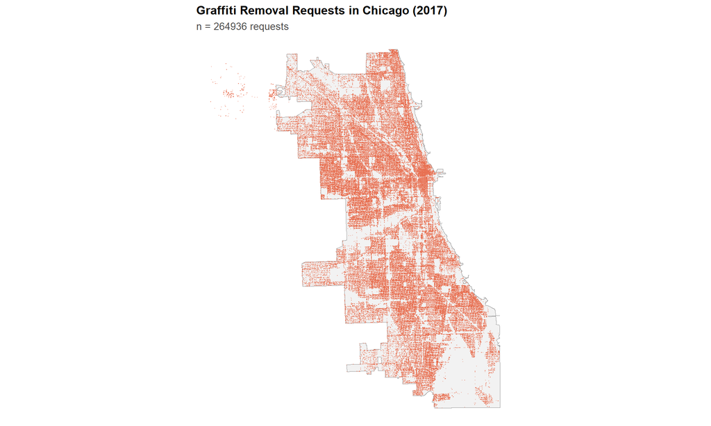

```r
ggplot() +
  geom_sf(data = chicagoBoundary, fill = "gray95", color = "gray60") +
  geom_sf(data = graffiti, color = "#e76f51", size = 0.1, alpha = 0.3) +
  labs(
    title = "Graffiti Removal Requests in Chicago (2017)",
    subtitle = paste0("n = ", nrow(graffiti), " requests")
  ) +
  theme_crime()
```

**Pattern observation:** Graffiti requests also show spatial clustering, with certain neighborhoods showing much higher concentrations of reports. This suggests that graffiti, like burglary, is not randomly distributed but follows spatial patterns tied to neighborhood characteristics.

**What I did:** I loaded Chicago’s boundary and police districts and reprojected all layers into the Illinois State Plane East system to ensure consistent spatial measurement. I then imported and cleaned the 2017 burglary dataset, filtering specifically for forcible-entry incidents and converting them into sf points. I visualized these burglaries using point maps and kernel density estimation to explore their spatial distribution. Finally, I loaded the 2017 graffiti removal requests, removed duplicates, converted them into sf points, and mapped their spatial patterns.

**Why this step is important:** This step prepares all spatial layers in a consistent coordinate system so that later operations—such as fishnet aggregation, distance calculations, and spatial cross-validation—are accurate. Exploring the raw data through maps helps determine whether burglary and graffiti exhibit meaningful spatial structure, which is necessary for constructing a predictive model. Graffiti represents a neighborhood disorder indicator that may explain variation in burglary risk, so confirming its coverage and spatial distribution is essential before building features.

**What I learned:** Both burglary incidents and graffiti requests show strong clustering rather than random dispersion. Burglary hotspots appear along several central and southern corridors, while graffiti requests are dense in many of the same areas. The high volume of graffiti reports provides rich spatial variation when aggregated to grid cells. These patterns confirm that place-based conditions matter and that graffiti is a reasonable predictor for modeling burglary counts. This provides a solid foundation for constructing the fishnet features used in the next step.

## Part 2: Create Fishnet Grid

### Generate Grid

I create a 500m × 500m fishnet grid to aggregate point-level crime data into a regular spatial structure suitable for count regression modeling.

```r
# Create 500m x 500m grid
fishnet <- st_make_grid(
  chicagoBoundary,
  cellsize = 500,
  square = TRUE
) %>%
  st_sf() %>%
  mutate(uniqueID = row_number())

# Keep only cells intersecting Chicago
fishnet <- fishnet[chicagoBoundary, ]
```

**Grid created:** 2458 cells of 500m × 500m each

### Aggregate Burglaries to Grid

```r
# Spatial join and count burglaries per cell
burglaries_fishnet <- st_join(burglaries, fishnet, join = st_within) %>%
  st_drop_geometry() %>%
  group_by(uniqueID) %>%
  summarize(countBurglaries = n())

# Join back to fishnet
fishnet <- fishnet %>%
  left_join(burglaries_fishnet, by = "uniqueID") %>%
  mutate(countBurglaries = replace_na(countBurglaries, 0))
```

**Burglary count distribution:**

```r
data.frame(
  Statistic = names(summary(fishnet$countBurglaries)),
  Value = as.numeric(summary(fishnet$countBurglaries))
) %>%
  mutate(Value = round(Value, 2)) %>%
  kable() %>%
  kable_styling()
```

| Statistic | Value |
| --- | --- |
| Min. | 0.0 |
| 1st Qu. | 0.0 |
| Median | 2.0 |
| Mean | 3.3 |
| 3rd Qu. | 5.0 |
| Max. | 41.0 |

**Cells with zero burglaries:** 30.3%

### Visualize Aggregated Counts

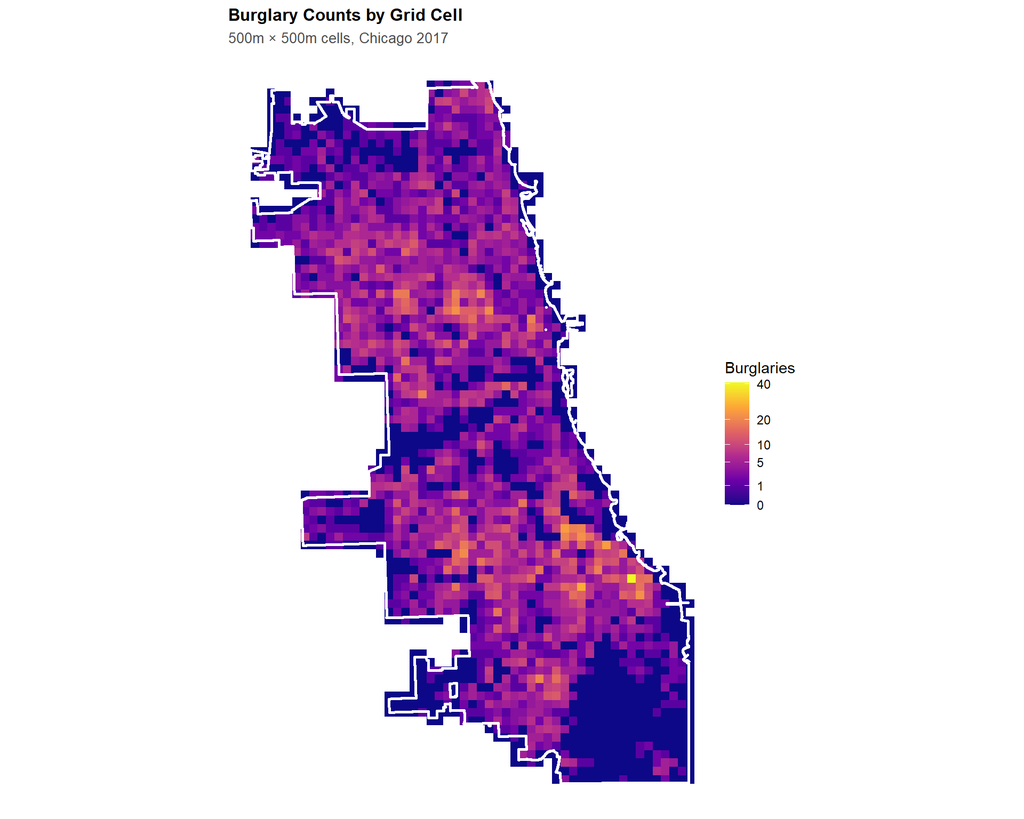

```r
ggplot() +
  geom_sf(data = fishnet, aes(fill = countBurglaries), color = NA) +
  geom_sf(data = chicagoBoundary, fill = NA, color = "white", linewidth = 1) +
  scale_fill_viridis_c(
    name = "Burglaries",
    option = "plasma",
    trans = "sqrt",
    breaks = c(0, 1, 5, 10, 20, 40)
  ) +
  labs(
    title = "Burglary Counts by Grid Cell",
    subtitle = "500m × 500m cells, Chicago 2017"
  ) +
  theme_crime()
```

**Distribution characteristics:** Most cells have 0-2 burglaries, with a long right tail showing a few cells with very high counts. This right-skewed distribution is typical of crime data and motivates the use of count regression models (Poisson or Negative Binomial) rather than standard linear regression.

**What I did:** I created a 500m × 500m fishnet grid covering the Chicago boundary and kept only the cells that intersect the city. This produced 2,458 uniform grid cells. I then performed a spatial join to count how many burglary incidents fell within each grid cell and merged these counts back into the fishnet. Finally, I summarized the distribution of burglary counts and mapped the aggregated values to visualize spatial variation at the grid-cell scale.

**Why this step is important:** A fishnet converts point-level crime events into a regular spatial structure, which is essential for predictive modeling. Regression models require each observation to represent a consistent spatial unit, and the grid ensures every cell has the same size and comparable meaning. Aggregating burglaries to grid cells also helps reduce noise in point data, revealing broader spatial patterns. Examining the distribution of counts is necessary for selecting an appropriate modeling approach; crime data typically exhibit overdispersion, which affects whether Poisson or Negative Binomial models are more suitable.

**What I learned:** Spatial aggregation reveals strong variation across the city even after smoothing point data into grid cells. Most grid cells contain between 0 and 2 burglaries, while a smaller number of cells have much higher counts, reaching up to 41 incidents. Roughly 30% of the cells contain zero burglaries, while a few hotspots dominate the upper tail of the distribution. This right-skewed pattern is typical of crime data and confirms the need for count-based models rather than linear models. The map also shows that burglary risk remains spatially clustered even after aggregation, indicating that neighborhood characteristics at the 500m scale are meaningful and appropriate for prediction.

## Part 3: Create Kernel Density Baseline

Before building complex models, I create a simple baseline using Kernel Density Estimation (KDE). This baseline asks: “What if crime just happens where it happened before?” with simple spatial smoothing and no predictors.

```r
# Convert burglaries to point pattern format
burglaries_ppp <- as.ppp(
  st_coordinates(burglaries),
  W = as.owin(st_bbox(chicagoBoundary))
)

# Calculate KDE with 1km bandwidth
kde_burglaries <- density.ppp(
  burglaries_ppp,
  sigma = 1000,
  edge = TRUE
)

# Convert to raster
kde_raster <- rast(kde_burglaries)

# Extract KDE values to fishnet cells
fishnet <- fishnet %>%
  mutate(
    kde_value = terra::extract(
      kde_raster,
      vect(fishnet),
      fun = mean,
      na.rm = TRUE
    )[, 2]
  )
```

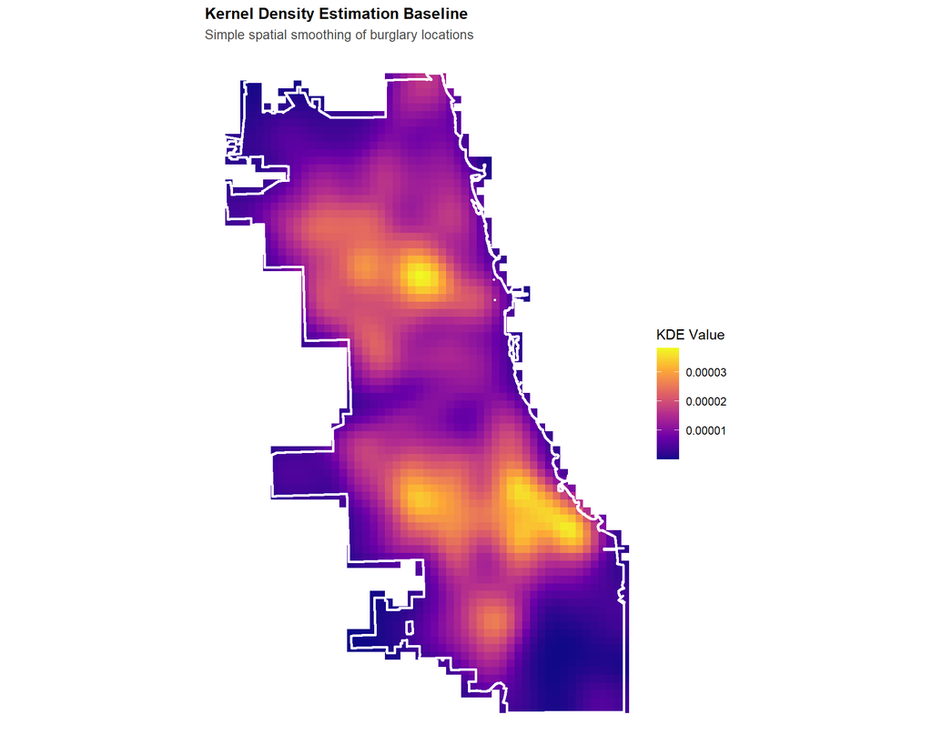

```r
ggplot() +
  geom_sf(data = fishnet, aes(fill = kde_value), color = NA) +
  geom_sf(data = chicagoBoundary, fill = NA, color = "white", linewidth = 1) +
  scale_fill_viridis_c(
    name = "KDE Value",
    option = "plasma"
  ) +
  labs(
    title = "Kernel Density Estimation Baseline",
    subtitle = "Simple spatial smoothing of burglary locations"
  ) +
  theme_crime()
```

**Baseline interpretation:** The KDE provides a simple prediction surface based purely on past crime locations. The complex model must outperform this baseline to justify its added complexity.

**What I did:** I converted the burglary point locations into a point pattern object and computed a Kernel Density Estimation (KDE) surface using a 1 km bandwidth. This produced a smoothed crime-intensity raster that reflects where burglaries have historically concentrated. I then extracted mean KDE values for each fishnet cell, integrating this baseline predictor into the dataset. Finally, I visualized the KDE surface over Chicago to examine the resulting spatial pattern.

**Why this step is important:** KDE provides the simplest possible spatial prediction model: it assumes that future crime is most likely to occur where past crime was concentrated, with smoothing to account for local diffusion. This creates an essential benchmark model. Any more complex predictive model—including those using graffiti or other features—should outperform this KDE baseline to justify the added complexity. KDE also helps capture large-scale spatial trends that might be difficult to learn from sparse count data alone.

**What I learned:** The KDE surface highlights broad, continuous hotspots across Chicago, especially in the central and near-south regions, which aligns with both the raw point distribution and the aggregated burglary counts. Because KDE smooths over local noise, it produces a stable risk surface that looks less fragmented than the fishnet counts. This confirms that burglary risk has strong spatial structure and spatial autocorrelation. It also reinforces the need for models that can capture both local indicator variables (e.g., graffiti) and larger-scale spatial patterns. The KDE results serve as a realistic, non-trivial baseline that any predictive model must exceed.

## Part 4: Create Spatial Predictor Variables

### Count of Graffiti per Cell

```r
# Aggregate graffiti to fishnet
graffiti_fishnet <- st_join(graffiti, fishnet, join = st_within) %>%
  st_drop_geometry() %>%
  group_by(uniqueID) %>%
  summarize(graffiti_count = n())

# Join to fishnet
fishnet <- fishnet %>%
  left_join(graffiti_fishnet, by = "uniqueID") %>%
  mutate(graffiti_count = replace_na(graffiti_count, 0))
```

**Graffiti distribution:**

```r
data.frame(
  Statistic = names(summary(fishnet$graffiti_count)),
  Value = as.numeric(summary(fishnet$graffiti_count))
) %>%
  mutate(Value = round(Value, 2)) %>%
  kable(caption = "Summary of graffiti counts per cell") %>%
  kable_styling(bootstrap_options = "striped")
```

Summary of graffiti counts per cell

| Statistic | Value |
| --- | --- |
| Min. | 0.00 |
| 1st Qu. | 18.00 |
| Median | 68.50 |
| Mean | 107.15 |
| 3rd Qu. | 148.00 |
| Max. | 1974.00 |

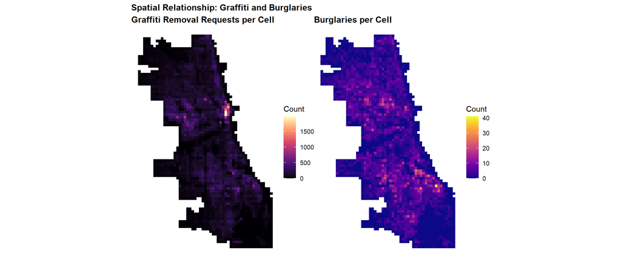

```r
p1 <- ggplot() +
  geom_sf(data = fishnet, aes(fill = graffiti_count), color = NA) +
  scale_fill_viridis_c(name = "Count", option = "magma") +
  labs(title = "Graffiti Removal Requests per Cell") +
  theme_crime()

p2 <- ggplot() +
  geom_sf(data = fishnet, aes(fill = countBurglaries), color = NA) +
  scale_fill_viridis_c(name = "Count", option = "plasma") +
  labs(title = "Burglaries per Cell") +
  theme_crime()

p1 + p2 +
  plot_annotation(title = "Spatial Relationship: Graffiti and Burglaries")
```

**Visual correlation:** Areas with high graffiti counts often overlap with areas of high burglary counts, suggesting a potential predictive relationship.

### Nearest Neighbor Distance Feature

```r
# Calculate coordinates
fishnet_coords <- st_coordinates(st_centroid(fishnet))
graffiti_coords <- st_coordinates(graffiti)

# Calculate k=3 nearest neighbors
nn_result <- get.knnx(graffiti_coords, fishnet_coords, k = 3)

# Add mean distance to fishnet
fishnet <- fishnet %>%
  mutate(graffiti_nn = rowMeans(nn_result$nn.dist))
```

**Average distance to 3 nearest graffiti requests:**

```r
data.frame(
  Statistic = names(summary(fishnet$graffiti_nn)),
  Feet = as.numeric(summary(fishnet$graffiti_nn))
) %>%
  mutate(Feet = round(Feet, 2)) %>%
  kable(caption = "Summary of k-NN distances") %>%
  kable_styling(bootstrap_options = "striped")
```

Summary of k-NN distances

| Statistic | Feet |
| --- | --- |
| Min. | 0.82 |
| 1st Qu. | 39.50 |
| Median | 63.75 |
| Mean | 126.60 |
| 3rd Qu. | 134.71 |
| Max. | 1507.28 |

### Identify Hot Spots Using Local Moran’s I

```r
# Calculate Local Moran's I
calculate_local_morans <- function(data, variable, k = 5) {
  coords <- st_coordinates(st_centroid(data))
  neighbors <- knn2nb(knearneigh(coords, k = k))
  weights <- nb2listw(neighbors, style = "W", zero.policy = TRUE)

  local_moran <- localmoran(data[[variable]], weights)
  mean_val <- mean(data[[variable]], na.rm = TRUE)

  data %>%
    mutate(
      local_i = local_moran[, 1],
      p_value = local_moran[, 5],
      is_significant = p_value < 0.05,
      moran_class = case_when(
        !is_significant ~ "Not Significant",
        local_i > 0 & .data[[variable]] > mean_val ~ "High-High",
        local_i > 0 & .data[[variable]] <= mean_val ~ "Low-Low",
        local_i < 0 & .data[[variable]] > mean_val ~ "High-Low",
        local_i < 0 & .data[[variable]] <= mean_val ~ "Low-High",
        TRUE ~ "Not Significant"
      )
    )
}

fishnet <- calculate_local_morans(fishnet, "graffiti_count", k = 5)
```

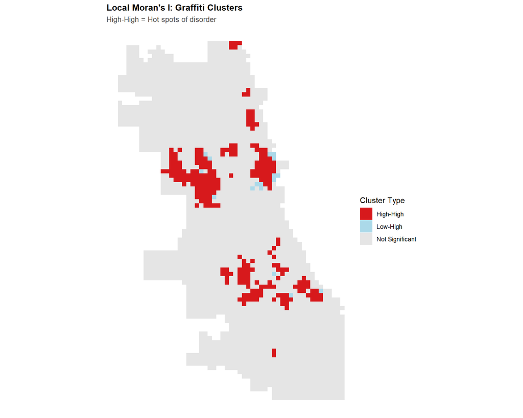

```r
ggplot() +
  geom_sf(data = fishnet, aes(fill = moran_class), color = NA) +
  scale_fill_manual(
    values = c(
      "High-High" = "#d7191c",
      "High-Low" = "#fdae61",
      "Low-High" = "#abd9e9",
      "Low-Low" = "#2c7bb6",
      "Not Significant" = "gray90"
    ),
    name = "Cluster Type"
  ) +
  labs(
    title = "Local Moran's I: Graffiti Clusters",
    subtitle = "High-High = Hot spots of disorder"
  ) +
  theme_crime()
```

**Hot spots identified:** 243 cells show significant High-High clustering

### Distance to Hot Spots

```r
# Get centroids of High-High cells
hotspots <- fishnet %>%
  filter(moran_class == "High-High") %>%
  st_centroid()

# Calculate distance from each cell to nearest hot spot
if (nrow(hotspots) > 0) {
  fishnet <- fishnet %>%
    mutate(
      dist_to_hotspot = as.numeric(
        st_distance(st_centroid(fishnet), hotspots %>% st_union())
      )
    )
} else {
  fishnet <- fishnet %>%
    mutate(dist_to_hotspot = 0)
}
```

**Distance to nearest hotspot:**

```r
data.frame(
  Statistic = names(summary(fishnet$dist_to_hotspot)),
  Feet = as.numeric(summary(fishnet$dist_to_hotspot))
) %>%
  mutate(Feet = round(Feet, 2)) %>%
  kable(caption = "Distance to nearest graffiti hotspot") %>%
  kable_styling(bootstrap_options = "striped")
```

Distance to nearest graffiti hotspot

| Statistic | Feet |
| --- | --- |
| Min. | 0.00 |
| 1st Qu. | 1000.00 |
| Median | 2236.07 |
| Mean | 2906.43 |
| 3rd Qu. | 4301.16 |
| Max. | 12041.59 |

**What I did:** I counted how many graffiti removal requests occurred in each grid cell. I then compared this map with burglary counts to see if the patterns matched. I also calculated how close each cell is to nearby graffiti using k-nearest neighbors. To capture clustering, I ran Local Moran’s I to find “High-High” graffiti hotspots and then measured how far each cell is from the nearest hotspot.

**Why this step is important:** These steps create the predictor variables that the model will use. Graffiti counts show how much disorder is inside each cell, while the distance measures show how close a cell is to surrounding disorder. The hotspot analysis identifies areas where graffiti is unusually concentrated—information that may help explain where burglaries happen.

**What I learned:** Graffiti is highly uneven across the city: some cells have almost none, while others have extremely high counts. Areas with lots of graffiti often overlap with areas of high burglary, which suggests a possible relationship. The nearest-neighbor distances show that most cells are still close to some graffiti activity. The hotspot map highlights several clear clusters of disorder, many in areas that also see more burglary. Overall, these graffiti-based features seem useful for predicting burglary patterns.

## Part 5: Join Police Districts for Cross-Validation

```r
# Join district information to fishnet
fishnet <- st_join(
  fishnet,
  policeDistricts,
  join = st_within,
  left = TRUE
) %>%
  filter(!is.na(District))
```

**Districts represented:** 22 police districts

**What I did:** I assigned each grid cell to a police district using a spatial join.

**Why this step is important:** This lets us run spatial cross-validation, where the model is tested on completely different districts instead of random samples.

**What I learned:** Almost all districts are represented in the fishnet, giving enough geographic variety to meaningfully test how well the model generalizes across space.

## Part 6: Model Fitting

### Prepare Modeling Data

```r
# Create clean modeling dataset
fishnet_model <- fishnet %>%
  st_drop_geometry() %>%
  dplyr::select(
    uniqueID,
    District,
    countBurglaries,
    graffiti_count,
    graffiti_nn,
    dist_to_hotspot
  ) %>%
  na.omit()
```

**Modeling dataset:** 1708 observations with 5 variables

### Fit Poisson Regression

```r
# Fit Poisson model
model_poisson <- glm(
  countBurglaries ~ graffiti_count + graffiti_nn + dist_to_hotspot,
  data = fishnet_model,
  family = "poisson"
)

summary(model_poisson)
```

```
Call:
glm(formula = countBurglaries ~ graffiti_count + graffiti_nn +
    dist_to_hotspot, family = "poisson", data = fishnet_model)

Coefficients:
                    Estimate   Std. Error z value            Pr(>|z|)
(Intercept)      2.145961011  0.031187500  68.808 <0.0000000000000002 ***
graffiti_count   0.000678190  0.000069411   9.771 <0.0000000000000002 ***
graffiti_nn     -0.009914097  0.000396455 -25.007 <0.0000000000000002 ***
dist_to_hotspot -0.000142562  0.000007907 -18.030 <0.0000000000000002 ***
---
Signif. codes:  0 '***' 0.001 '**' 0.01 '*' 0.05 '.' 0.1 ' ' 1

(Dispersion parameter for poisson family taken to be 1)

    Null deviance: 6995.7  on 1707  degrees of freedom
Residual deviance: 3795.0  on 1704  degrees of freedom
AIC: 8011.9

Number of Fisher Scoring iterations: 5
```

### Check for Overdispersion

```r
# Calculate dispersion parameter
dispersion <- sum(residuals(model_poisson, type = "pearson")^2) /
              model_poisson$df.residual
```

**Dispersion parameter:** 2.27

**Assessment:** Since the dispersion parameter (2.27) is greater than 1.5, there is evidence of overdispersion. A Negative Binomial model is recommended.

### Fit Negative Binomial Regression

```r
# Fit Negative Binomial model
model_nb <- glm.nb(
  countBurglaries ~ graffiti_count + graffiti_nn + dist_to_hotspot,
  data = fishnet_model
)

summary(model_nb)
```

```
Call:
glm.nb(formula = countBurglaries ~ graffiti_count + graffiti_nn +
    dist_to_hotspot, data = fishnet_model, init.theta = 2.962845902,
    link = log)

Coefficients:
                   Estimate  Std. Error z value            Pr(>|z|)
(Intercept)      2.02721889  0.05479307  36.998 <0.0000000000000002 ***
graffiti_count   0.00133693  0.00015054   8.881 <0.0000000000000002 ***
graffiti_nn     -0.01065985  0.00054696 -19.489 <0.0000000000000002 ***
dist_to_hotspot -0.00011609  0.00001139 -10.194 <0.0000000000000002 ***
---
Signif. codes:  0 '***' 0.001 '**' 0.01 '*' 0.05 '.' 0.1 ' ' 1

(Dispersion parameter for Negative Binomial(2.9628) family taken to be 1)

    Null deviance: 3428.7  on 1707  degrees of freedom
Residual deviance: 1746.9  on 1704  degrees of freedom
AIC: 7163.5

Number of Fisher Scoring iterations: 1

              Theta:  2.963
          Std. Err.:  0.198

 2 x log-likelihood:  -7153.491
```

**Model comparison:**

```r
data.frame(
  Model = c("Poisson", "Negative Binomial"),
  AIC = c(AIC(model_poisson), AIC(model_nb))
) %>%
  mutate(AIC = round(AIC, 2)) %>%
  kable(caption = "Model fit comparison (lower AIC is better)") %>%
  kable_styling(bootstrap_options = "striped")
```

Model fit comparison (lower AIC is better)

| Model | AIC |
| --- | --- |
| Poisson | 8011.87 |
| Negative Binomial | 7163.49 |

**Selected model:** The Negative Binomial model has a lower AIC (7163.49 vs 8011.87), indicating better fit. This model accounts for overdispersion in the data.

**What I did:** I built both Poisson and Negative Binomial models using the graffiti-based predictors and compared their performance.

**Why this step is important:** This evaluates whether the predictors explain burglary variation and helps choose a model that fits the data correctly, especially given overdispersion.

**What I learned:** The data were overdispersed, and the Negative Binomial model clearly fit better (lower AIC), making it the appropriate model to use going forward.

## Part 7: Spatial Cross-Validation

### Leave-One-Group-Out Cross-Validation

```r
# Get unique districts
districts <- unique(fishnet_model$District)
cv_results <- tibble()

# LOGO-CV loop
for (i in seq_along(districts)) {
  test_district <- districts[i]

  # Split data
  train_data <- fishnet_model %>% filter(District != test_district)
  test_data <- fishnet_model %>% filter(District == test_district)

  # Fit model on training data
  model_cv <- glm.nb(
    countBurglaries ~ graffiti_count + graffiti_nn + dist_to_hotspot,
    data = train_data
  )

  # Predict on test data
  test_data <- test_data %>%
    mutate(prediction = predict(model_cv, test_data, type = "response"))

  # Calculate metrics
  mae <- mean(abs(test_data$countBurglaries - test_data$prediction))
  rmse <- sqrt(mean((test_data$countBurglaries - test_data$prediction)^2))

  # Store results
  cv_results <- bind_rows(
    cv_results,
    tibble(
      fold = i,
      test_district = test_district,
      n_test = nrow(test_data),
      mae = mae,
      rmse = rmse
    )
  )
}
```

**Cross-validation summary:**

```r
cv_results %>%
  summarise(
    `Mean MAE` = mean(mae),
    `Mean RMSE` = mean(rmse),
    `SD MAE` = sd(mae),
    `SD RMSE` = sd(rmse)
  ) %>%
  mutate(across(everything(), ~round(., 2))) %>%
  kable(caption = "Overall cross-validation performance") %>%
  kable_styling(bootstrap_options = "striped")
```

Overall cross-validation performance

| Mean MAE | Mean RMSE | SD MAE | SD RMSE |
| --- | --- | --- | --- |
| 3.12 | 5.3 | 2.56 | 7.75 |

**Detailed results by district:**

```r
cv_results %>%
  arrange(desc(mae)) %>%
  mutate(across(c(mae, rmse), ~round(., 2))) %>%
  kable(
    caption = "Spatial Cross-Validation Results by Police District",
    col.names = c("Fold", "District", "N Test", "MAE", "RMSE")
  ) %>%
  kable_styling(bootstrap_options = c("striped", "hover"))
```

Spatial Cross-Validation Results by Police District

| Fold | District | N Test | MAE | RMSE |
| --- | --- | --- | --- | --- |
| 11 | 1ST | 28 | 13.05 | 38.50 |
| 15 | 18TH | 30 | 7.06 | 12.64 |
| 7 | 3RD | 43 | 4.86 | 6.64 |
| 14 | 11TH | 43 | 3.72 | 4.85 |
| 12 | 12TH | 73 | 3.51 | 4.71 |
| 4 | 6TH | 63 | 2.94 | 3.97 |
| 10 | 10TH | 63 | 2.72 | 3.61 |
| 8 | 2ND | 56 | 2.67 | 3.35 |
| 16 | 25TH | 85 | 2.58 | 3.51 |
| 6 | 7TH | 52 | 2.53 | 3.25 |
| 17 | 14TH | 46 | 2.52 | 3.70 |
| 13 | 15TH | 32 | 2.36 | 2.77 |
| 18 | 19TH | 63 | 2.29 | 2.94 |
| 22 | 24TH | 41 | 2.17 | 2.61 |
| 5 | 8TH | 197 | 2.13 | 3.31 |
| 21 | 20TH | 30 | 2.13 | 2.42 |
| 3 | 22ND | 112 | 1.85 | 2.50 |
| 9 | 9TH | 107 | 1.81 | 2.33 |
| 1 | 5TH | 98 | 1.74 | 2.36 |
| 20 | 17TH | 82 | 1.62 | 2.13 |
| 2 | 4TH | 235 | 1.25 | 2.81 |
| 19 | 16TH | 129 | 1.19 | 1.67 |

**Performance assessment:** The average MAE of 3.12 indicates that on average, predictions are off by approximately 3.1 burglaries per cell. Some districts are easier to predict than others, which may reflect different neighborhood dynamics or data quality across Chicago.

**What I did:** I used leave-one-district-out cross-validation to test the model on districts it was never trained on.

**Why this step is important:** This checks whether the model can generalize to new geographic areas instead of only performing well where it was trained.

**What I learned:** The model performs reasonably well overall (MAE ≈ 3.1), but accuracy varies across districts, suggesting that some neighborhoods have more complex or unique burglary patterns than others.

## Part 8: Model Predictions and Comparison

### Generate Final Predictions

```r
# Fit final model on all 2017 data
final_model <- glm.nb(
  countBurglaries ~ graffiti_count + graffiti_nn + dist_to_hotspot,
  data = fishnet_model
)

# Add predictions to fishnet
fishnet <- fishnet %>%
  mutate(
    prediction_nb = predict(
      final_model,
      fishnet_model,
      type = "response"
    )[match(uniqueID, fishnet_model$uniqueID)]
  )

# Normalize KDE to same scale
kde_sum <- sum(fishnet$kde_value, na.rm = TRUE)
count_sum <- sum(fishnet$countBurglaries, na.rm = TRUE)

fishnet <- fishnet %>%
  mutate(
    prediction_kde = (kde_value / kde_sum) * count_sum
  )
```

### Compare Predictions Visually

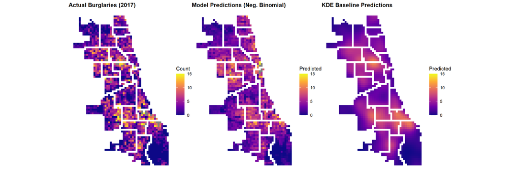

```r
p1 <- ggplot() +
  geom_sf(data = fishnet, aes(fill = countBurglaries), color = NA) +
  scale_fill_viridis_c(name = "Count", option = "plasma", limits = c(0, 15)) +
  labs(title = "Actual Burglaries (2017)") +
  theme_crime()

p2 <- ggplot() +
  geom_sf(data = fishnet, aes(fill = prediction_nb), color = NA) +
  scale_fill_viridis_c(name = "Predicted", option = "plasma", limits = c(0, 15)) +
  labs(title = "Model Predictions (Neg. Binomial)") +
  theme_crime()

p3 <- ggplot() +
  geom_sf(data = fishnet, aes(fill = prediction_kde), color = NA) +
  scale_fill_viridis_c(name = "Predicted", option = "plasma", limits = c(0, 15)) +
  labs(title = "KDE Baseline Predictions") +
  theme_crime()

p1 + p2 + p3
```

### Quantitative Comparison

```r
# Calculate performance metrics
comparison <- fishnet %>%
  st_drop_geometry() %>%
  filter(!is.na(prediction_nb), !is.na(prediction_kde)) %>%
  summarize(
    model_mae = mean(abs(countBurglaries - prediction_nb)),
    model_rmse = sqrt(mean((countBurglaries - prediction_nb)^2)),
    kde_mae = mean(abs(countBurglaries - prediction_kde)),
    kde_rmse = sqrt(mean((countBurglaries - prediction_kde)^2))
  )

comparison %>%
  pivot_longer(everything(), names_to = "metric", values_to = "value") %>%
  separate(metric, into = c("approach", "metric"), sep = "_") %>%
  pivot_wider(names_from = metric, values_from = value) %>%
  mutate(across(where(is.numeric), ~round(., 2))) %>%
  kable(
    caption = "Model Performance Comparison on 2017 Data",
    col.names = c("Approach", "MAE", "RMSE")
  ) %>%
  kable_styling(bootstrap_options = c("striped", "hover"))
```

Model Performance Comparison on 2017 Data

| Approach | MAE | RMSE |
| --- | --- | --- |
| model | 2.28 | 3.95 |
| kde | 2.18 | 3.10 |